# Caitlin Clark Career Stat. Insights

Mia Fitzgerald & Angela McMahon

4/8/2026

## Introduction

We used a data set that tracks Caitlin Clark’s complete college basketball career at the University of Iowa, spanning from the start of the 2020-2021 season to the end of the 2023-2024 season. It measures her game-by-game performance across various categories, including her scoring volume, three-point shooting, assists, and defensive stats like rebounds and steals. These metrics provide a clear picture of her offensive efficiency and how much she contributed to the team’s success in each match up throughout her four years. The data set contains a sample size of exactly 139 games, representing every game she made an appearance at during her time as a Hawkeye. Link: https://www.sports-reference.com/cbb/players/caitlin-clark-1/gamelog/

## Data Import

From the data set table, made the data into a csv file format. Copied and pasted this into a text file. Here the column names including symbols like % and a missing column name were altered to correspond well with R. This file was saved as a csv file and imported into the R markdown file. Once the data set was loaded in, for both the columns ‘Away’ and ‘Games Started’ the ‘Yes’ notation was symbolized by a character. So, this was changed to a Yes or No input. The ‘Results’ column also had both W or L for wins and losses and the score at the end of each game. This column was separated into ‘Results’ which records wins ‘W’ and losses ‘L’, then ‘Points’ which is the score at the end of the game for each team. To fill missing values and merge we used too_few/too_many inside of widening the column. Once these adjustments were made, this new, tidy data set was restored.

```r
library(readr)
library(tidyr)
CC_career_stats <- read_csv("CC_career_stats.csv")
CC_career_stats <- CC_career_stats%>%
  mutate(Away=if_else(Away=="@","Yes","No"), Away=coalesce(Away, "No"))%>%
  mutate(GS=if_else(GS=="*","Yes", "No"))%>%
  separate_wider_delim(
    cols=Result,
    delim=" ",
    names=c("Result", "Points"),
    too_few="align_start",
    too_many="merge"
  )

head(CC_career_stats)
```

```
## # A tibble: 6 × 35
##      Rk  Gcar   Gtm Date       Team  Away  Opp   Type  Result Points GS       MP
##   <dbl> <dbl> <dbl> <date>     <chr> <chr> <chr> <chr> <chr>  <chr>  <chr> <dbl>
## 1     1     1     1 2020-11-25 Iowa  No    Nort… REG … W      96-81  Yes      26
## 2     2     2     2 2020-12-02 Iowa  Yes   Drake REG … W      103-97 Yes      35
## 3     3     3     3 2020-12-05 Iowa  No    Wisc… REG … W      85-78  Yes      31
## 4     4     4     4 2020-12-09 Iowa  No    Iowa… REG … W      82-80  Yes      36
## 5     5     5     5 2020-12-12 Iowa  Yes   Mich… REG … L      82-86  Yes      36
## 6     6     6     6 2020-12-22 Iowa  No    West… REG … W      92-65  Yes      28
## # ℹ 23 more variables: FG <dbl>, FGA <dbl>, FGP <dbl>, `3P` <dbl>, `3PA` <dbl>,
## #   `3PP` <dbl>, `2P` <dbl>, `2PA` <dbl>, `2PP` <dbl>, eFGP <dbl>, FT <dbl>,
## #   FTA <dbl>, FTP <dbl>, ORB <dbl>, DRB <dbl>, TRB <dbl>, AST <dbl>,
## #   STL <dbl>, BLK <dbl>, TOV <dbl>, PF <dbl>, PTS <dbl>, GmSc <dbl>
```

## Exploratory Data Analysis

### Instances Caitlin Shot Over 60% from the 3-Point Line

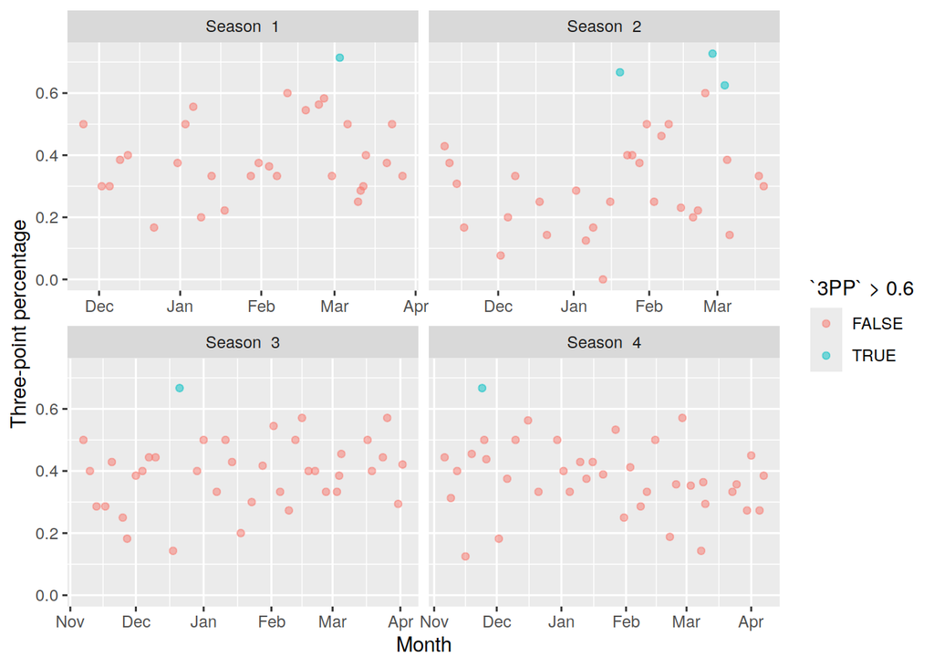

```r
#instances where she shot over 60 percent from the 3 over her career (More consistent in last two seasons)
CC_career_stats %>%
  filter(!is.na(Date)) %>%
  mutate(Season = ifelse(month(Date) >= 10, year(Date), year(Date) - 1)) %>%
  mutate(Season_Label = paste("Season ", as.numeric(factor(Season)))) %>%
  ggplot(aes(x = Date, y = `3PP`)) +
  geom_point(aes(color = `3PP` > 0.6), alpha = 0.5) +
  facet_wrap(~Season_Label, scales = "free_x") +
  labs(x="Month", y="Three-point percentage")
```

Note that she had more instances in her second season but also that she reaches 60 percent at least once as season.

### Caitlin’s Assist’s in Home vs. Away Games

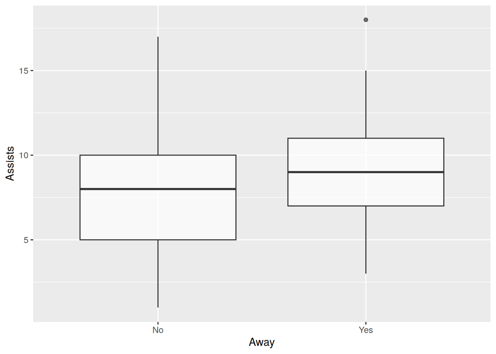

```r
CC_career_stats %>%
  filter(AST < 100) %>% #outlier removed
  ggplot(aes(x = Away, y = AST)) +
  geom_boxplot(alpha = 0.7)+
  labs(y="Assists")
```

She averaged more assists at away games than home games.

### Instances where Caitlin Scored over 40 Points in her Career

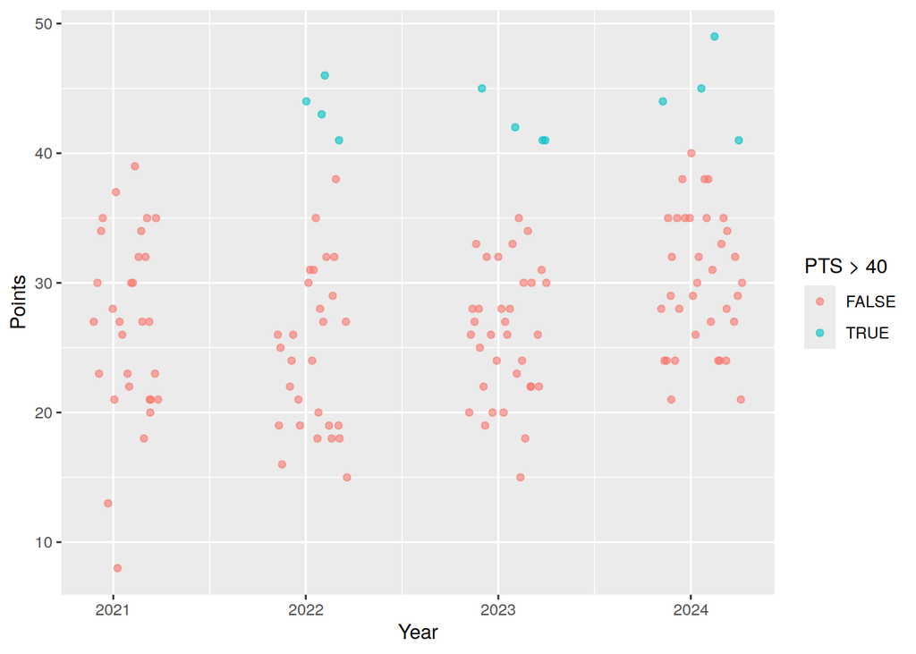

```r
CC_career_stats %>%
  filter(PTS < 100) %>%
  ggplot(aes(x = Date, y = PTS, color = PTS > 40)) +
  geom_point(alpha = 0.6)+
  labs(x = "Year", y="Points")
```

### Difference in Counts of Rebound Type Throughout her Career

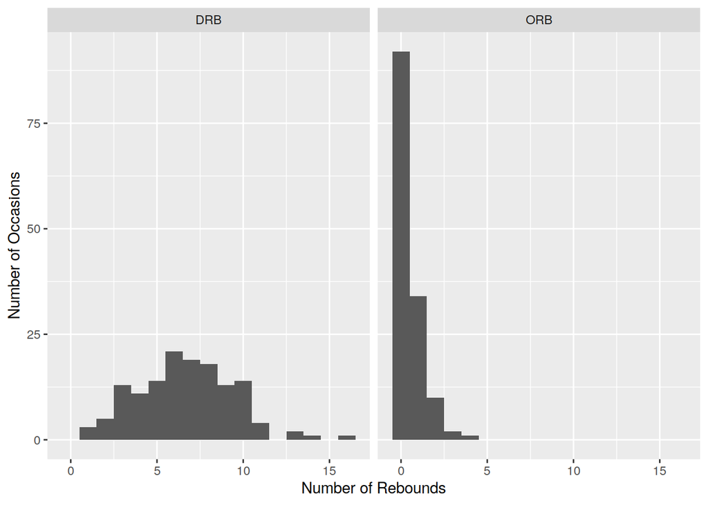

```r
CC_career_stats %>%
  pivot_longer(cols = c(ORB, DRB), names_to = "Rebound_Type", values_to = "Count") %>%
  filter(Count < 20)%>%
  ggplot(aes(x=Count))+
  geom_histogram(binwidth=1)+
  facet_wrap(~Rebound_Type)+
  labs(x="Number of Rebounds", y="Number of Occasions")
```

The number of offensive rebounds are consistently low while her defense rebound count is much higher and more spread out.

### Dates, Results, and Field Goal Percentage of Limited Turnover Games (0 & 1) in her Career

```r
CC_career_stats %>%
  select(Date, TOV, FGP, Result) %>%
  filter(TOV == 0 | TOV == 1) %>%
  kable()
```

| Date | TOV | FGP | Result |
| --- | --- | --- | --- |
| 2022-01-02 | 1 | 0.692 | W |
| 2022-03-20 | 1 | 0.211 | L |
| 2022-11-20 | 1 | 0.556 | W |
| 2022-11-25 | 0 | 0.522 | W |
| 2023-01-14 | 1 | 0.600 | W |
| 2023-11-06 | 0 | 0.647 | W |
| 2023-11-09 | 1 | 0.419 | W |
| 2024-01-31 | 1 | 0.500 | W |

### Games Caitlin had Greater than 12 Assists Lead to Wins

```r
CC_career_stats %>%
  select(TOV, AST, Date, Result) %>%
  filter(!is.na(Date), AST > 12) %>%
  kable()
```

| TOV | AST | Date | Result |
| --- | --- | --- | --- |
| 5 | 13 | 2020-12-02 | W |
| 4 | 14 | 2021-02-28 | W |
| 4 | 18 | 2022-01-25 | W |
| 4 | 14 | 2023-01-11 | W |
| 7 | 15 | 2023-01-23 | W |
| 4 | 14 | 2023-02-05 | W |
| 2 | 17 | 2023-03-05 | W |
| 12 | 15 | 2024-02-08 | W |
| 5 | 13 | 2024-02-15 | W |
| 6 | 15 | 2024-03-09 | W |
| 2 | 15 | 2024-03-30 | W |

### Difference in Result Based on her Assists

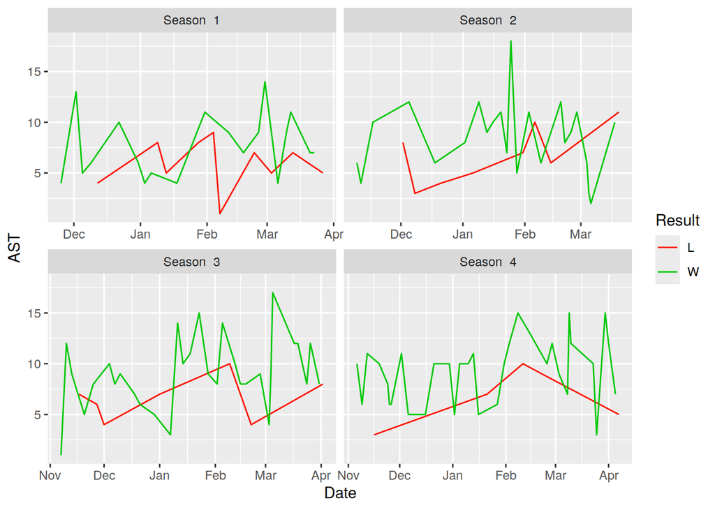

```r
CC_career_stats %>%
  filter(AST < 100) %>%
  mutate(Season = ifelse(month(Date) >= 10, year(Date), year(Date) - 1)) %>%
  mutate(Season_Label = paste("Season ", as.numeric(factor(Season)))) %>%
  ggplot(aes(x = Date, y = AST, color = Result, group = interaction(Result, Season))) +
  scale_color_manual(values = c("W" = "#00C805", "L" = "#FF1300")) +
  geom_line() +
  facet_wrap(~Season_Label, scales = "free_x")
```

### Game Results with Day of the Week Count

```r
CC_career_stats%>%
  mutate(Weekday= wday(Date, label=TRUE, abbr=TRUE))%>%
  count(Result, Weekday)%>%
  drop_na(Weekday)%>%
  arrange(desc(n))%>%
  rename(Count=n)%>%
  kable()
```

| Result | Weekday | Count |
| --- | --- | --- |
| W | Sun | 29 |
| W | Sat | 21 |
| W | Thu | 17 |
| W | Wed | 16 |
| W | Fri | 13 |
| L | Sun | 9 |
| L | Thu | 9 |
| W | Mon | 7 |
| W | Tue | 6 |
| L | Sat | 4 |
| L | Tue | 3 |
| L | Wed | 3 |
| L | Mon | 2 |

The table above displays the day of the week and result of the game pair count. It is interesting to see there are the most wins on Saturday and Sunday. This could be due to having more games on weekend days compared to throughout the week, but more investigation is needed to make this conclusion.

### Number of Games Caitlin Played in each Month

```r
CC_career_stats%>%
  mutate(month= month(Date, label=TRUE, abbr=TRUE))%>%
  count(month)%>%
  drop_na(month)%>%
  kable()
```

| month | n |
| --- | --- |
| Jan | 32 |
| Feb | 30 |
| Mar | 29 |
| Apr | 4 |
| Nov | 20 |
| Dec | 24 |

We can see the distribution of games is higher in the winter months which makes sense with the sports season. However, we can also see she played in many games in March and some in April which could be March Madness games.

### Types of Games Played on the Weekends Versus Weekdays

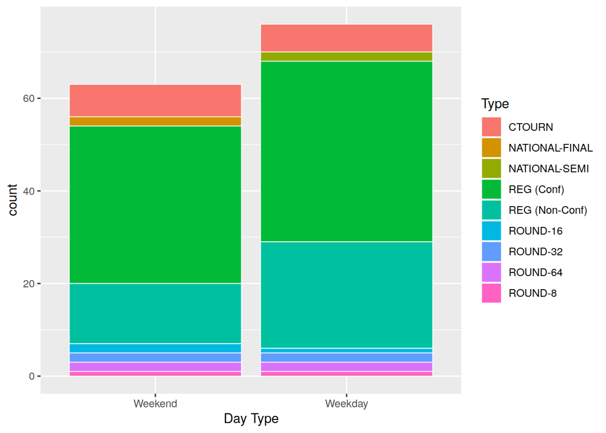

```r
CC_career_stats%>%
  mutate(WkDay=wday(Date, label=TRUE, abbr=TRUE))%>%
  mutate(WeekDays= fct_collapse(WkDay,
                               "Weekend"=c("Sun","Sat"),
                               "Weekday"=c("Mon","Tue","Wed","Thu","Fri")))%>%
  drop_na(WkDay)%>%
  ggplot(aes(x=WeekDays, fill=Type)) +
  geom_bar(color = "white", linewidth = 0.3) +  # Adding a white border
  labs(x = "Day Type")
```

```r
  #non-conf difference in the chart, everything else is split and more games during the week
```

Exploring the types of games she played in on the weekend versus the weekdays. Now we can see there is actually more games being played on the weekdays compared to the weekends. Highlighting the type of game helps us see how the amount they played in March Madness games (colors labeled starting with ‘ROUND’) and how often are those games on the weekend versus weekdays. We can see her and the team have been in more ROUND 16 games on the weekend compared to on the weekdays.

### Games Caitlin Played in per Season

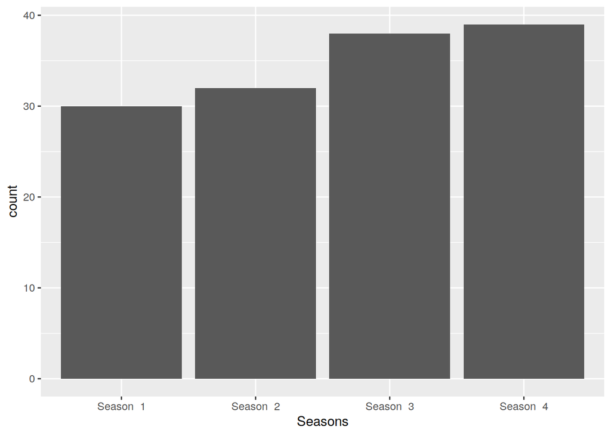

```r
CC_career_stats%>%
  mutate(Season = ifelse(month(Date) >= 10, year(Date), year(Date) - 1))%>%
  drop_na(Season)%>%
  mutate(Seasons = paste("Season ", as.numeric(factor(Season)))) %>%
  ggplot(aes(x=Seasons))+
  geom_bar()
```

Looking at the different seasons that Caitlin has played in, we can see the amount of games per season has increased gradually. However, she has played in about 30 games since the beginning of her career. The large jump between seasons 2 and 3 support her player development and determination.